# ndvi.max.doy.doy ~ snow.auc INLA

Jakob J. Assmann, Calum Hoad

2024-04-11

```r
knitr::opts_chunk$set(echo = TRUE)
# Dependencies
library(tidyverse)
library(sp)
library(gstat)
library(spdep)
library(spatialreg)
library(ggplot2)
library(cowplot)
library(colorspace)
library(pbapply)
library(broom)
library(kableExtra)
library(INLA)
library(cowplot)

# Opttional set to short inal summary
#inla.setOption(short.summary = TRUE)

# Optional: turn off scientific notation
options(scipen = 999)
```

## Load all data

Load Sentinel-2 data for each site (BL, KL, KH) and HLS S30 data for BL only.

```r
# Load data
s2.bl <- read_csv('../../data/combined-ndvi-snow/s2-bl-smooth-joined.csv',
                  show_col_types = FALSE) %>%
  st_as_sf(coords = c('X', 'Y'), remove = F, crs = 32621) %>%
  group_by(id) %>%
  filter(row_number() == 7) %>%
  ungroup()

# Kluane low
s2.kl <- read_csv('../../data/combined-ndvi-snow/s2-kl-smooth-joined.csv',
                  show_col_types = FALSE) %>%
  st_as_sf(coords = c('X', 'Y'), remove = F, crs = 32608) %>%
  group_by(id) %>%
  filter(row_number() == 7) %>%
  ungroup()

# Kluane high
s2.kh <- read_csv('../../data/combined-ndvi-snow/s2-kh-smooth-joined.csv',
                  show_col_types = FALSE) %>%
  st_as_sf(coords = c('X', 'Y'), remove = F, crs = 32608) %>%
  group_by(id) %>%
  filter(row_number() == 7) %>%
  ungroup()

# Blaesedalen, S30
s30.bl <- read_csv('../../data/combined-ndvi-snow/s30-bl-smooth-joined.csv',
                   show_col_types = FALSE) %>%
  st_as_sf(coords = c('X', 'Y'), remove = F, crs = 32621) %>%
  group_by(id) %>%
  filter(row_number() == 7) %>%
  ungroup()
```

# Blaesedalen, Sentinel-2

## Prepare “node” vector for INLA matern2d model

INLA nodes are arranged as sequential numbers where numbers ascend column-wise from the top-left corner of the grid towards the bottom-right. See Fig 7.1 in this document: https://becarioprecario.bitbucket.io/inla-gitbook/ch-spatial.html

In our case, we can derive the column and row numbers from the UTM coordinates as follows:

col_number = (x - min(x)) / 10  
row_number = (max(y) - y) / 10

We can then assign a regularly increasing index (1:n), by infilling the cells no accounted for.

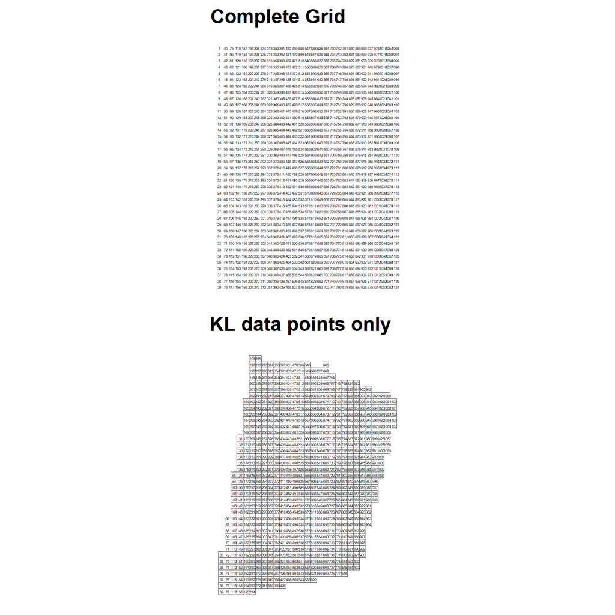

```r
# Calculate row and col_numbers
input.data <- s2.bl %>%
  # Calculate min X and max >
  mutate(min_x = min(.$X),
         max_y = max(.$Y)) %>%
  # Calczulate colum and row numbers for each cell (top-left to bottom-right corner)
  # We shift by one a R is 1- based
  mutate(col_number = 1 + ((X - min_x) / 10),
         row_number = 1 + ((max_y - Y) / 10)) %>%
  # Arrange dataset accordingly
  arrange(col_number, row_number)

# Derrive spatial index in INLA fashion (running number)
# Optain number of cols and rows
n_col = max(input.data$col_number)
n_row = max(input.data$row_number)
# Expand grid and add index
complete_grid <- expand.grid(1:n_col, 1:n_row) %>%
  # Rename columns
  select(col_number = Var1, row_number = Var2) %>%
  # Rearrange same as data frame above (top-left to bottom-right)
  arrange(col_number, row_number) %>%
  # Generate index ("node")
  mutate(node = 1:nrow(.))

# Add node to input.data, skipping those with no data (left_join)
input.data <- input.data %>%
  left_join(complete_grid, by = c("col_number", "row_number"))

# Plot to visualise
complete_grid_plot <- ggplot() +
  geom_text(data = complete_grid,
            mapping = aes(x = col_number, y = row_number, label = node),
            size = 1) +
  labs(title = "Complete Grid") +
  scale_y_reverse() +
  coord_equal() +
  theme_map()
kl_node_plot <- ggplot() +
  geom_sf(data = st_buffer(st_geometry(input.data), 5, endCapStyle = "SQUARE"),
          fill = NA) +
  geom_sf_text(data = input.data,
               aes(label = node),
               size = 1) +
  labs(title = "KL data points only") +
  theme_map()

plot_grid(complete_grid_plot,
          kl_node_plot,
          nrow = 2)
```

Now we have a vector (“node”) that represents the spatial arrangement of the pixels in a way that INLA can understand.

## Fitting a simple INLA model

Next, we fit a super simple INLA model, not worrying about priors for now.

```r
# Specify formula
formula_matern <- ndvi.max.doy ~ snow.auc +
                  f(node,
                    model = "matern2d",
                    nrow = n_row,
                    ncol = n_col)
# Fit model
model_matern <- inla(formula = formula_matern,
                     data = input.data,
                     family = "gaussian",
                     control.predictor = list(compute = TRUE),
                     control.compute = list(dic = TRUE,
                                            waic = TRUE,
                                            cpo = TRUE,
                                            return.marginals.predictor = TRUE),
                     keep = TRUE)
# Print summary
summary(model_matern)
```

```
##
## Call:
##    c("inla.core(formula = formula, family = family, contrasts = contrasts,
##    ", " data = data, quantiles = quantiles, E = E, offset = offset, ", "
##    scale = scale, weights = weights, Ntrials = Ntrials, strata = strata,
##    ", " lp.scale = lp.scale, link.covariates = link.covariates, verbose =
##    verbose, ", " lincomb = lincomb, selection = selection, control.compute
##    = control.compute, ", " control.predictor = control.predictor,
##    control.family = control.family, ", " control.inla = control.inla,
##    control.fixed = control.fixed, ", " control.mode = control.mode,
##    control.expert = control.expert, ", " control.hazard = control.hazard,
##    control.lincomb = control.lincomb, ", " control.update =
##    control.update, control.lp.scale = control.lp.scale, ", "
##    control.pardiso = control.pardiso, only.hyperparam = only.hyperparam,
##    ", " inla.call = inla.call, inla.arg = inla.arg, num.threads =
##    num.threads, ", " keep = keep, working.directory = working.directory,
##    silent = silent, ", " inla.mode = inla.mode, safe = FALSE, debug =
##    debug, .parent.frame = .parent.frame)" )
## Time used:
##     Pre = 1.62, Running = 29.6, Post = 0.488, Total = 31.7
## Fixed effects:
##                mean    sd 0.025quant 0.5quant 0.975quant    mode kld
## (Intercept) 228.116 0.463    227.234  228.106    229.052 228.106   0
## snow.auc      0.202 0.019      0.165    0.202      0.238   0.202   0
##
## Random effects:
##   Name     Model
##     node Matern2D model
##
## Model hyperparameters:
##                                              mean        sd 0.025quant
## Precision for the Gaussian observations 20657.394 10693.119   6655.289
## Precision for node                          0.111     0.024      0.071
## Range for node                              6.513     0.814      5.099
##                                          0.5quant 0.975quant      mode
## Precision for the Gaussian observations 18439.900  47538.412 14515.049
## Precision for node                          0.109      0.163     0.106
## Range for node                              6.450      8.299     6.297
##
## Deviance Information Criterion (DIC) ...............: -4923.23
## Deviance Information Criterion (DIC, saturated) ....: 1690.02
## Effective number of parameters .....................: 862.02
##
## Watanabe-Akaike information criterion (WAIC) ...: -5128.70
## Effective number of parameters .................: 495.02
##
## Marginal log-Likelihood:  -1449.86
## CPO, PIT is computed
## Posterior summaries for the linear predictor and the fitted values are computed
## (Posterior marginals needs also 'control.compute=list(return.marginals.predictor=TRUE)')
```

The credible interval does not overlap with zero, or, given the data and model the 95% interval of the posterior distribution indicates a positive slope with a mean of 0.202.

Let’s retrieve the fitted values and marginal predictions.

```r
# Calculate marginal predictions depending on snow.auc only
input.data$preds <- model_matern$summary.fixed[1,1] +
                 input.data$snow.auc * model_matern$summary.fixed[2,1]
# Add model fitted values and residuals to data frame
input.data$fitted <- model_matern$summary.linear.predictor$mean
input.data$residuals <- input.data$ndvi.max.doy - model_matern$summary.linear.predictor$mean
```

Produce variograms to better understand the spatial structure of the data and to assess whether the INLA model with non-informative priors appropriately accounts for spatial autocorrelation.

```
## [1] "a possible solution MIGHT be to scale semivariances and/or distances"
```

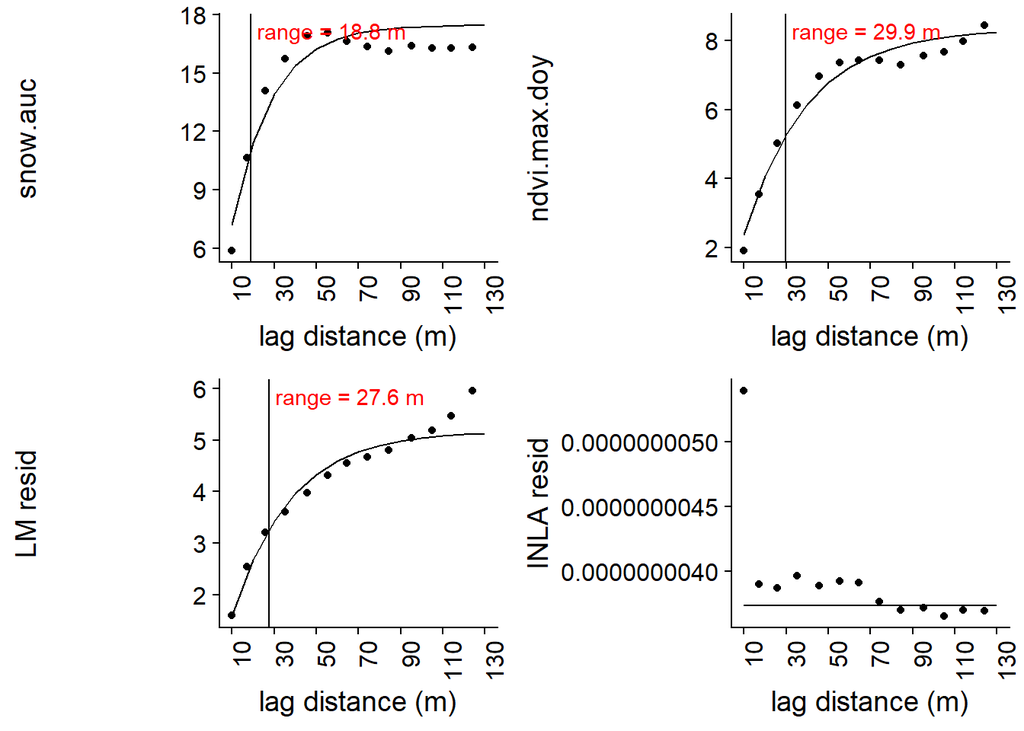

Graph fitted values and marginal predictions.

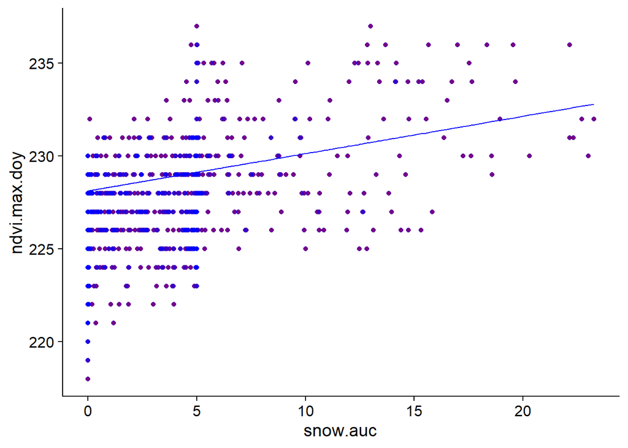

```r
# Graph data, fitted values and predictions
ggplot(data = input.data) +
  geom_point(aes(x = snow.auc, y= ndvi.max.doy),
             colour = 'red') +
  geom_point(aes(x = snow.auc, y = fitted),
             colour = "blue",
             alpha = 0.5) +
  geom_line(aes(x = snow.auc, preds),
            colour = "blue") +
  theme_cowplot()
```

Let’s have a look at how the predictions are distributed in space:

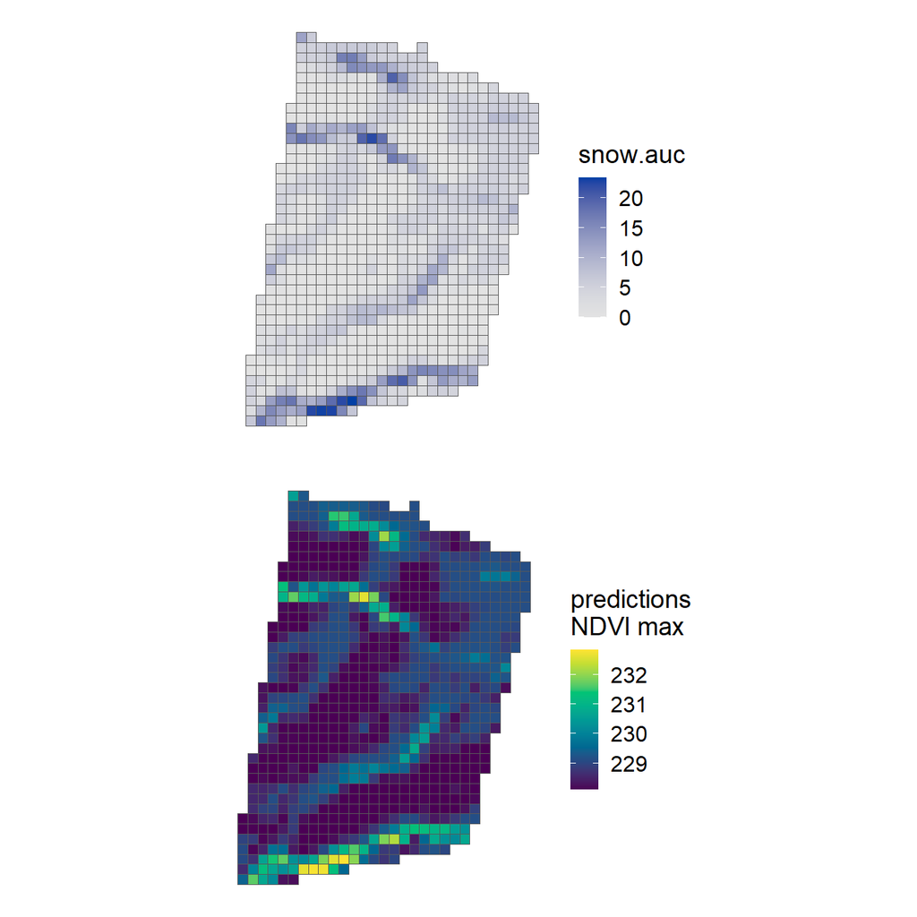

```r
plot_grid(ggplot() +
  geom_sf(data = st_buffer(input.data, 5, endCapStyle = "SQUARE"),
          aes(fill = snow.auc)) +
  scale_fill_continuous_sequential("blue") +
  labs(fill = "snow.auc") +
  theme_map(),
  ggplot() +
  geom_sf(data = st_buffer(input.data, 5, endCapStyle = "SQUARE"),
          aes(fill = preds)) +
  scale_fill_continuous_sequential("viridis", rev = F) +
  labs(fill = "predictions\nNDVI max") +
  theme_map(),
  nrow = 2)
```

Next we need to check whether there is still any autocorrelation in the residuals and whether these follow a Gaussian distribution (as assumed).

## Graph residuals

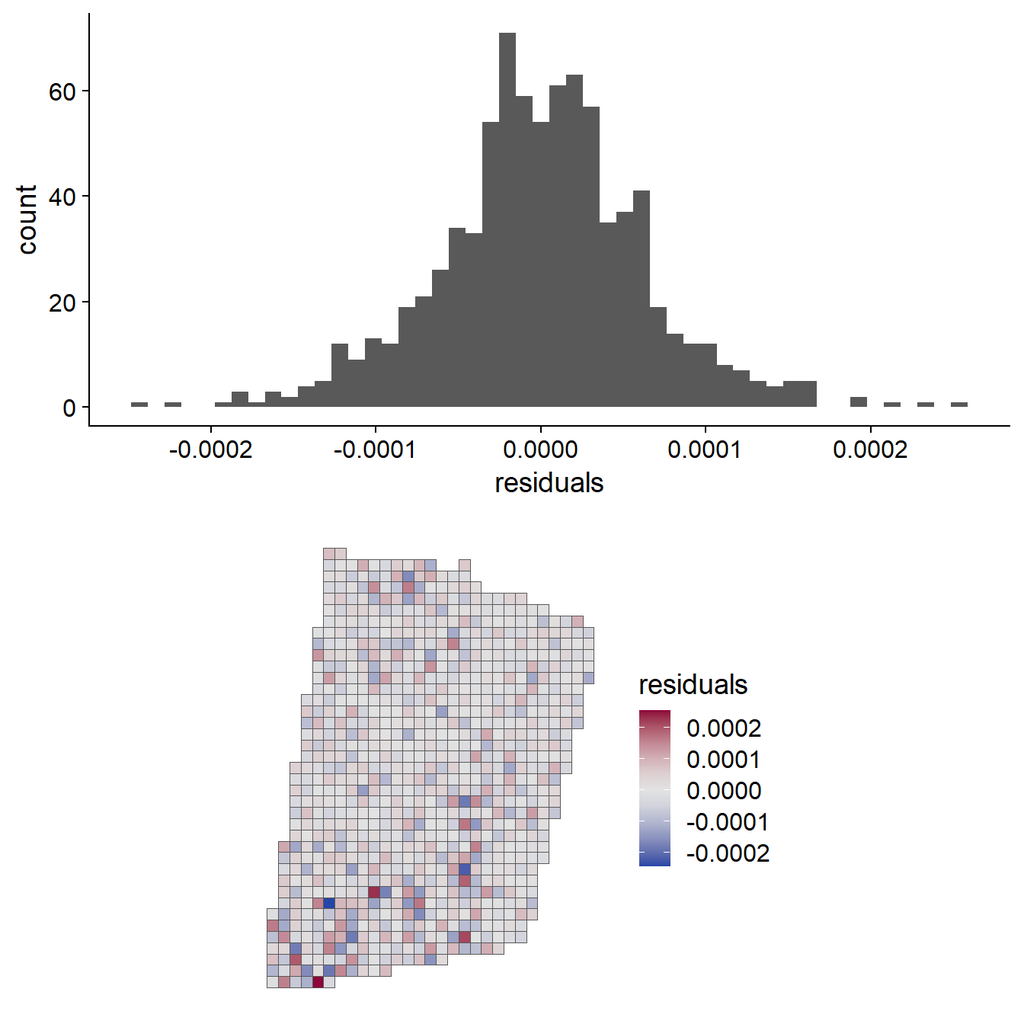

```r
# Graph residuals as histogram and in space
plot_grid(ggplot(input.data) +
  geom_histogram(aes(x = residuals), bins = 50) +
  labs(x = "residuals") +
  theme_cowplot(),
ggplot() +
  geom_sf(data = st_buffer(input.data, 5, endCapStyle = "SQUARE"), aes(fill = residuals)) +
  scale_fill_continuous_diverging() +
  theme_map(),
nrow = 2)
```

The histogram of the residuals follows a nice normal distribution - great!

It also seems like the model does an excellent job at accounting for the spatial autocorrelation. The residual are are seemingly randomly distributed in space.

As a last check, let’s look at the variation accounted for by the latent spatial effect.

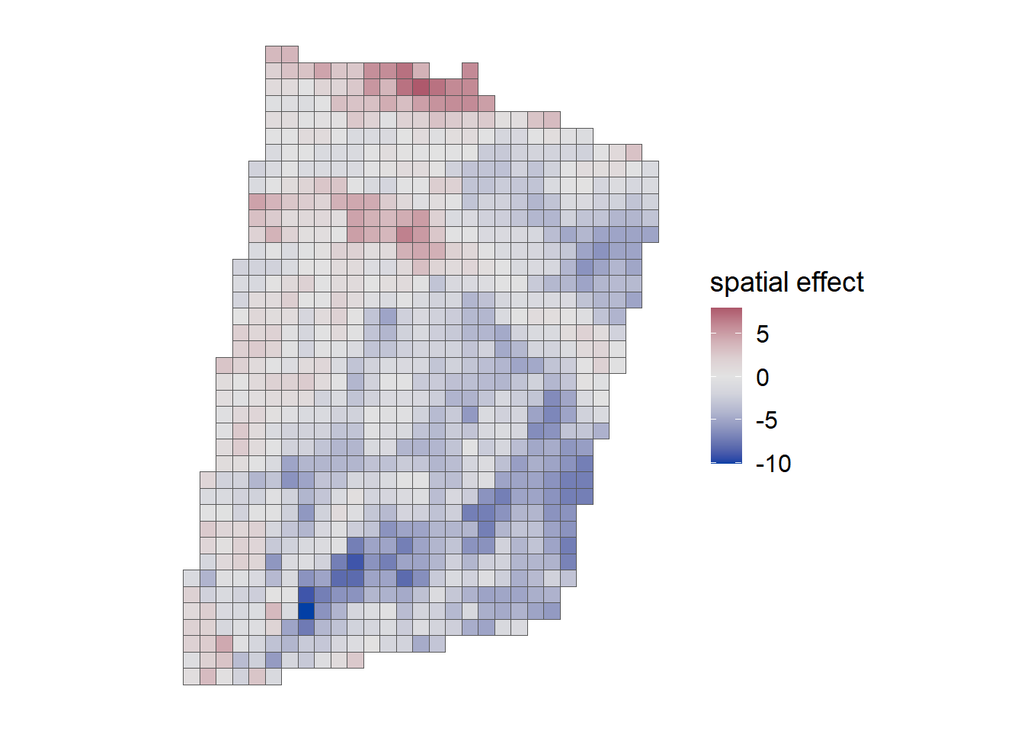

```r
ggplot() +
  geom_sf(data = st_buffer(input.data, 5, endCapStyle = "SQUARE"),
          aes(fill = ndvi.max.doy - preds - residuals)) +
  scale_fill_continuous_diverging() +
  labs(fill = "spatial effect") +
  theme_map()
```

The latent spatial effect of the model manages to account for a lot of the residual variation. That makes a lot of ecological sense, as we’d think that the majority in NDVI variation is not explained by our predictor.

The way I understand the spatial latent effect is that INLA fits an an “random error term” to each individual node where the error term is described by a matern function based on the surrounding neighbourhood of the node. I am not 100% certain that is really how it works, but will run this past a colleague to dig deeper.

# Kluane Low, Sentinel-2

## Prepare “node” vector for INLA matern2d model

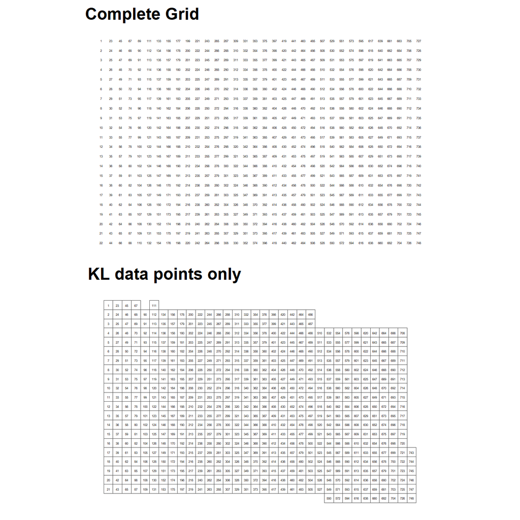

```r
# Calculate row and col_numbers
input.data <- s2.kl %>%
  # Calculate min X and max >
  mutate(min_x = min(.$X),
         max_y = max(.$Y)) %>%
  # Calczulate colum and row numbers for each cell (top-left to bottom-right corner)
  # We shift by one a R is 1- based
  mutate(col_number = 1 + ((X - min_x) / 10),
         row_number = 1 + ((max_y - Y) / 10)) %>%
  # Arrange dataset accordingly
  arrange(col_number, row_number)

# Derrive spatial index in INLA fashion (running number)
# Optain number of cols and rows
n_col = max(input.data$col_number)
n_row = max(input.data$row_number)
# Expand grid and add index
complete_grid <- expand.grid(1:n_col, 1:n_row) %>%
  # Rename columns
  select(col_number = Var1, row_number = Var2) %>%
  # Rearrange same as data frame above (top-left to bottom-right)
  arrange(col_number, row_number) %>%
  # Generate index ("node")
  mutate(node = 1:nrow(.))

# Add node to input.data, skipping those with no data (left_join)
input.data <- input.data %>%
  left_join(complete_grid, by = c("col_number", "row_number"))

# Plot to visualise
complete_grid_plot <- ggplot() +
  geom_text(data = complete_grid,
            mapping = aes(x = col_number, y = row_number, label = node),
            size = 1) +
  labs(title = "Complete Grid") +
  scale_y_reverse() +
  coord_equal() +
  theme_map()
kl_node_plot <- ggplot() +
  geom_sf(data = st_buffer(st_geometry(input.data), 5, endCapStyle = "SQUARE"),
          fill = NA) +
  geom_sf_text(data = input.data,
               aes(label = node),
               size = 1) +
  labs(title = "KL data points only") +
  theme_map()

plot_grid(complete_grid_plot,
          kl_node_plot,
          nrow = 2)
```

## Fitting a simple INLA model

```r
# Specify formula
formula_matern <- ndvi.max.doy ~ snow.auc +
                  f(node,
                    model = "matern2d",
                    nrow = n_row,
                    ncol = n_col)
# Fit model
model_matern <- inla(formula = formula_matern,
                     data = input.data,
                     family = "gaussian",
                     control.predictor = list(compute = TRUE),
                     control.compute = list(dic = TRUE,
                                            waic = TRUE,
                                            cpo = TRUE,
                                            return.marginals.predictor = TRUE),
                     keep = TRUE)
# Print summary
summary(model_matern)
```

```
##
## Call:
##    c("inla.core(formula = formula, family = family, contrasts = contrasts,
##    ", " data = data, quantiles = quantiles, E = E, offset = offset, ", "
##    scale = scale, weights = weights, Ntrials = Ntrials, strata = strata,
##    ", " lp.scale = lp.scale, link.covariates = link.covariates, verbose =
##    verbose, ", " lincomb = lincomb, selection = selection, control.compute
##    = control.compute, ", " control.predictor = control.predictor,
##    control.family = control.family, ", " control.inla = control.inla,
##    control.fixed = control.fixed, ", " control.mode = control.mode,
##    control.expert = control.expert, ", " control.hazard = control.hazard,
##    control.lincomb = control.lincomb, ", " control.update =
##    control.update, control.lp.scale = control.lp.scale, ", "
##    control.pardiso = control.pardiso, only.hyperparam = only.hyperparam,
##    ", " inla.call = inla.call, inla.arg = inla.arg, num.threads =
##    num.threads, ", " keep = keep, working.directory = working.directory,
##    silent = silent, ", " inla.mode = inla.mode, safe = FALSE, debug =
##    debug, .parent.frame = .parent.frame)" )
## Time used:
##     Pre = 0.818, Running = 14.9, Post = 0.377, Total = 16.1
## Fixed effects:
##                mean    sd 0.025quant 0.5quant 0.975quant    mode kld
## (Intercept) 215.224 0.227    214.779  215.224    215.670 215.224   0
## snow.auc      0.425 0.040      0.347    0.425      0.503   0.425   0
##
## Random effects:
##   Name     Model
##     node Matern2D model
##
## Model hyperparameters:
##                                              mean        sd 0.025quant
## Precision for the Gaussian observations 16323.993 10708.157   3588.510
## Precision for node                          0.135     0.076      0.033
## Range for node                             11.569     3.905      6.347
##                                          0.5quant 0.975quant     mode
## Precision for the Gaussian observations 13750.715  43874.907 9182.673
## Precision for node                          0.119      0.321    0.087
## Range for node                             10.804     21.422    9.248
##
## Deviance Information Criterion (DIC) ...............: -3878.74
## Deviance Information Criterion (DIC, saturated) ....: 1296.57
## Effective number of parameters .....................: 636.59
##
## Watanabe-Akaike information criterion (WAIC) ...: -3951.06
## Effective number of parameters .................: 430.74
##
## Marginal log-Likelihood:  -812.30
## CPO, PIT is computed
## Posterior summaries for the linear predictor and the fitted values are computed
## (Posterior marginals needs also 'control.compute=list(return.marginals.predictor=TRUE)')
```

The credible interval does not overlap with zero, or, given the data and model the 95% interval of the posterior distribution indicates a positive slope with a mean of 0.425.

Let’s retrieve the fitted values and marginal predictions.

```r
# Calculate marginal predictions depending on snow.auc only
input.data$preds <- model_matern$summary.fixed[1,1] +
                 input.data$snow.auc * model_matern$summary.fixed[2,1]
# Add model fitted values and residuals to data frame
input.data$fitted <- model_matern$summary.linear.predictor$mean
input.data$residuals <- input.data$ndvi.max.doy - model_matern$summary.linear.predictor$mean
```

Produce variograms to better understand the spatial structure of the data and to assess whether the INLA model with non-informative priors appropriately accounts for spatial autocorrelation.

```
## [1] "a possible solution MIGHT be to scale semivariances and/or distances"
```

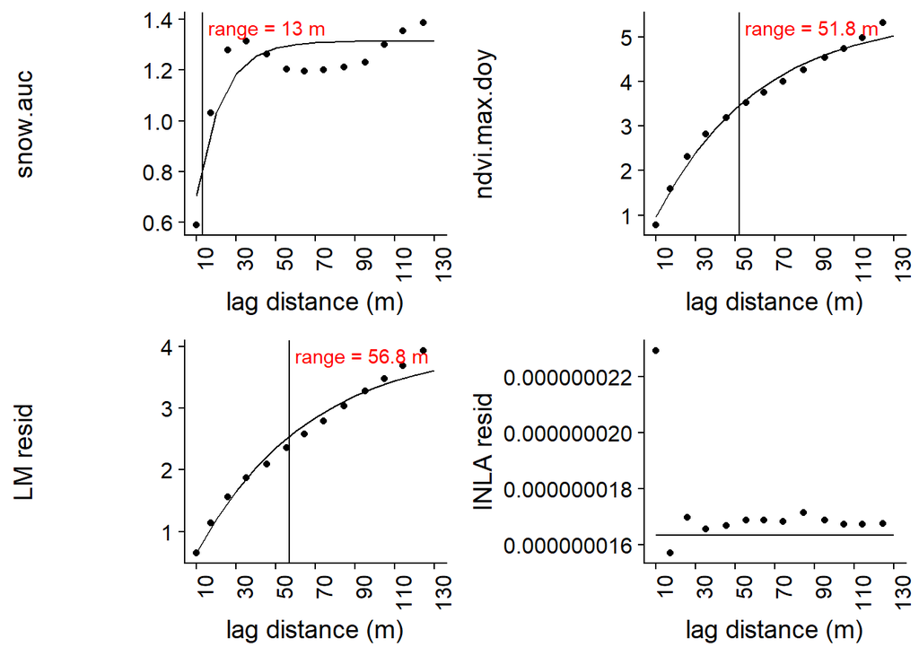

Graph fitted values and marginal predictions.

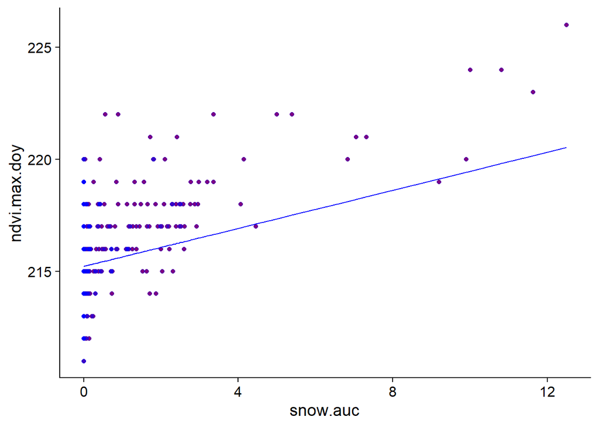

```r
# Graph data, fitted values and predictions
ggplot(data = input.data) +
  geom_point(aes(x = snow.auc, y= ndvi.max.doy),
             colour = 'red') +
  geom_point(aes(x = snow.auc, y = fitted),
             colour = "blue",
             alpha = 0.5) +
  geom_line(aes(x = snow.auc, preds),
            colour = "blue") +
  theme_cowplot()
```

The fitted values (blue) are very close to the observed values (red). Suggesting that the model (including the spatial random effect) does manage to account for a lot of the variation in the data (very good!). The fitted slope and intercept seem both reasonable given the observed data.

Let’s have a look at how the predictions are distributed in space:

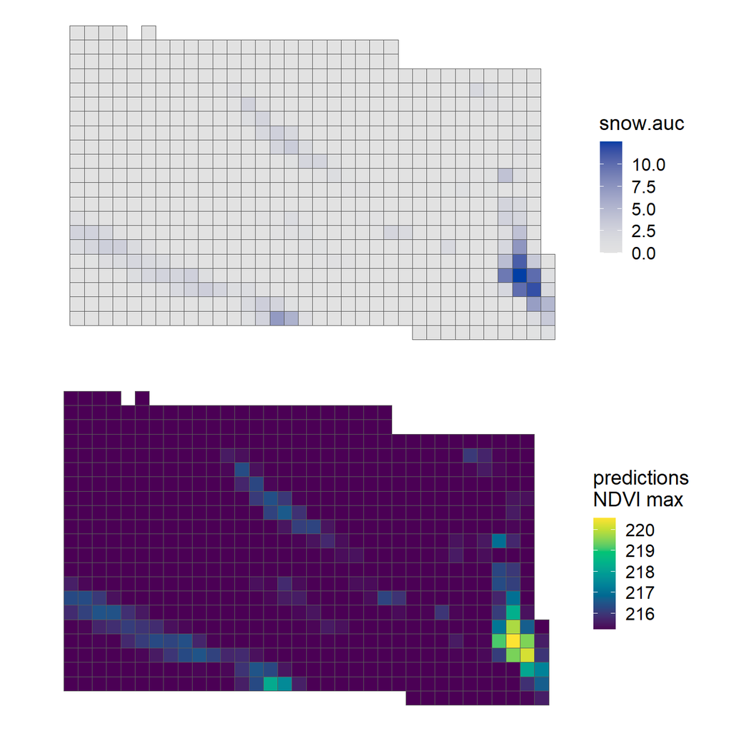

```r
plot_grid(ggplot() +
  geom_sf(data = st_buffer(input.data, 5, endCapStyle = "SQUARE"),
          aes(fill = snow.auc)) +
  scale_fill_continuous_sequential("blue") +
  labs(fill = "snow.auc") +
  theme_map(),
  ggplot() +
  geom_sf(data = st_buffer(input.data, 5, endCapStyle = "SQUARE"),
          aes(fill = preds)) +
  scale_fill_continuous_sequential("viridis", rev = F) +
  labs(fill = "predictions\nNDVI max") +
  theme_map(),
  nrow = 2)
```

This looks great and seems to make sense given the hypothesised relationship.

Next we need to check whether there is still any autocorrelation in the residuals and whether these follow a Gaussian distribution (as assumed).

## Graph residuals

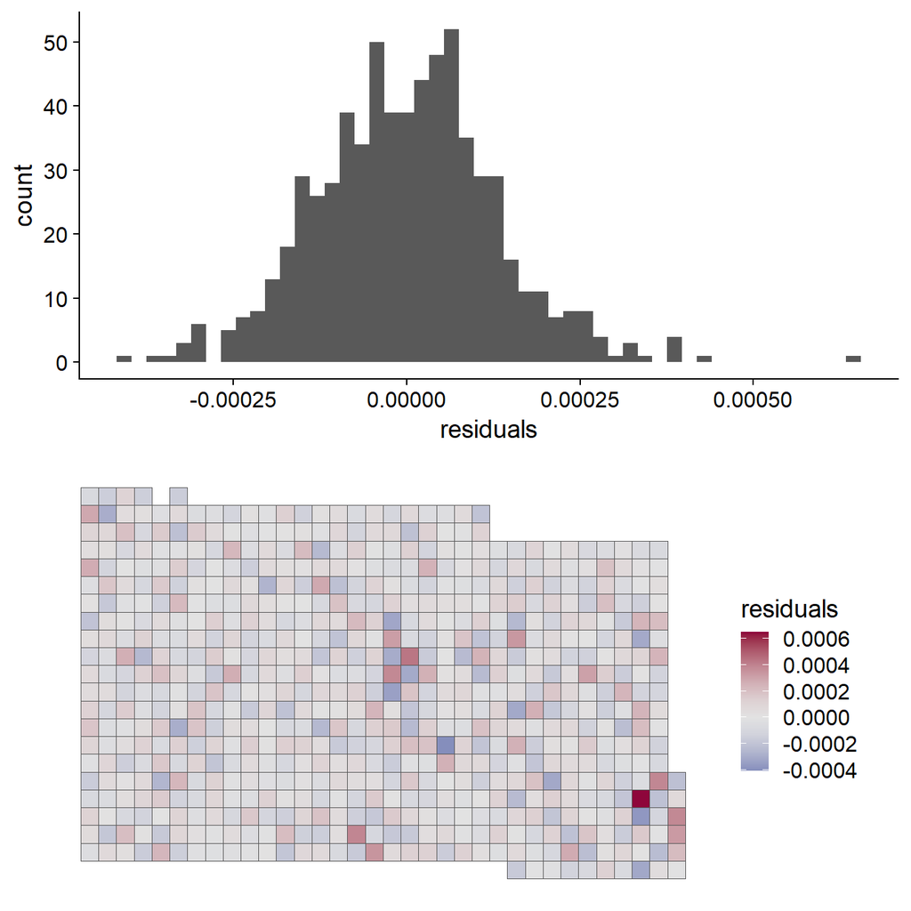

```r
# Graph residuals as histogram and in space
plot_grid(ggplot(input.data) +
  geom_histogram(aes(x = residuals), bins = 50) +
  labs(x = "residuals") +
  theme_cowplot(),
ggplot() +
  geom_sf(data = st_buffer(input.data, 5, endCapStyle = "SQUARE"), aes(fill = residuals)) +
  scale_fill_continuous_diverging() +
  theme_map(),
nrow = 2)
```

The histogram of the residuals follows a nice normal distribution - great!

It also seems like the model does an excellent job at accounting for the spatial autocorrelation. The residual are are seemingly randomly distributed in space.

As a last check, let’s look at the variation accounted for by the latent spatial effect.

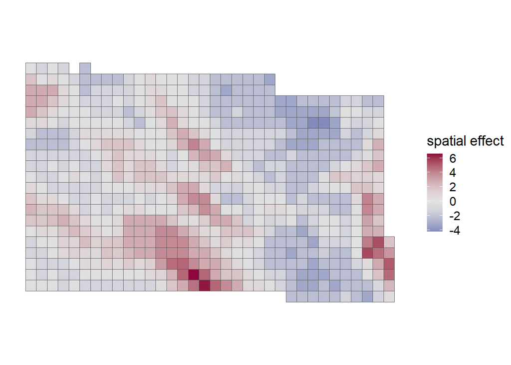

```r
ggplot() +
  geom_sf(data = st_buffer(input.data, 5, endCapStyle = "SQUARE"),
          aes(fill = ndvi.max.doy - preds - residuals)) +
  scale_fill_continuous_diverging() +
  labs(fill = "spatial effect") +
  theme_map()
```

The latent spatial effect of the model manages to account for a lot of the residual variation. That makes a lot of ecological sense, as we’d think that the majority in NDVI variation is not explained by our predictor.

# Kluane High, Sentinel-2

## Prepare “node” vector for INLA matern2d model

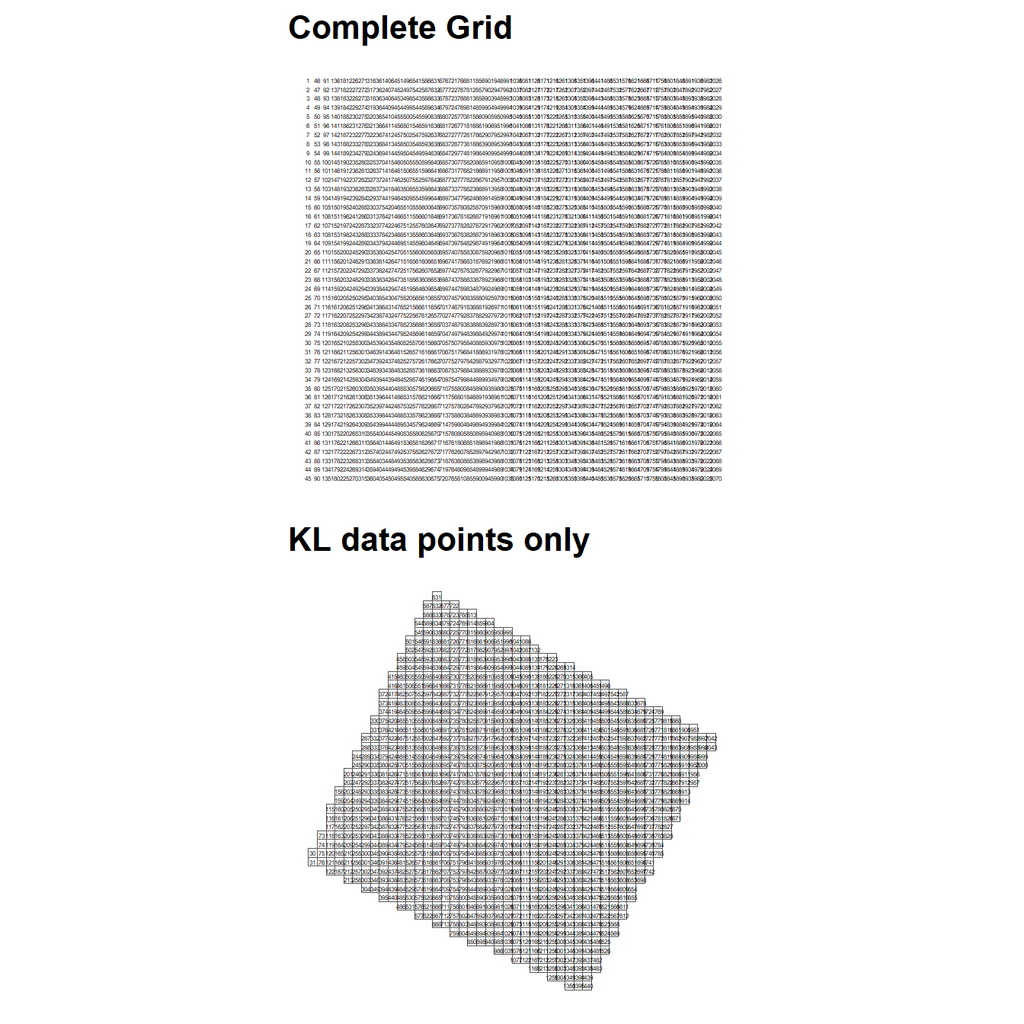

```r
# Calculate row and col_numbers
input.data <- s2.kh %>%
  # Calculate min X and max >
  mutate(min_x = min(.$X),
         max_y = max(.$Y)) %>%
  # Calczulate colum and row numbers for each cell (top-left to bottom-right corner)
  # We shift by one a R is 1- based
  mutate(col_number = 1 + ((X - min_x) / 10),
         row_number = 1 + ((max_y - Y) / 10)) %>%
  # Arrange dataset accordingly
  arrange(col_number, row_number)

# Derrive spatial index in INLA fashion (running number)
# Optain number of cols and rows
n_col = max(input.data$col_number)
n_row = max(input.data$row_number)
# Expand grid and add index
complete_grid <- expand.grid(1:n_col, 1:n_row) %>%
  # Rename columns
  select(col_number = Var1, row_number = Var2) %>%
  # Rearrange same as data frame above (top-left to bottom-right)
  arrange(col_number, row_number) %>%
  # Generate index ("node")
  mutate(node = 1:nrow(.))

# Add node to input.data, skipping those with no data (left_join)
input.data <- input.data %>%
  left_join(complete_grid, by = c("col_number", "row_number"))

# Plot to visualise
complete_grid_plot <- ggplot() +
  geom_text(data = complete_grid,
            mapping = aes(x = col_number, y = row_number, label = node),
            size = 1) +
  labs(title = "Complete Grid") +
  scale_y_reverse() +
  coord_equal() +
  theme_map()
kl_node_plot <- ggplot() +
  geom_sf(data = st_buffer(st_geometry(input.data), 5, endCapStyle = "SQUARE"),
          fill = NA) +
  geom_sf_text(data = input.data,
               aes(label = node),
               size = 1) +
  labs(title = "KL data points only") +
  theme_map()

plot_grid(complete_grid_plot,
          kl_node_plot,
          nrow = 2)
```

## Fitting a simple INLA model

```r
# Specify formula
formula_matern <- ndvi.max.doy ~ snow.auc +
                  f(node,
                    model = "matern2d",
                    nrow = n_row,
                    ncol = n_col)
# Fit model
model_matern <- inla(formula = formula_matern,
                     data = input.data,
                     family = "gaussian",
                     control.predictor = list(compute = TRUE),
                     control.compute = list(dic = TRUE,
                                            waic = TRUE,
                                            cpo = TRUE,
                                            return.marginals.predictor = TRUE),
                     keep = TRUE)
# Print summary
summary(model_matern)
```

```
##
## Call:
##    c("inla.core(formula = formula, family = family, contrasts = contrasts,
##    ", " data = data, quantiles = quantiles, E = E, offset = offset, ", "
##    scale = scale, weights = weights, Ntrials = Ntrials, strata = strata,
##    ", " lp.scale = lp.scale, link.covariates = link.covariates, verbose =
##    verbose, ", " lincomb = lincomb, selection = selection, control.compute
##    = control.compute, ", " control.predictor = control.predictor,
##    control.family = control.family, ", " control.inla = control.inla,
##    control.fixed = control.fixed, ", " control.mode = control.mode,
##    control.expert = control.expert, ", " control.hazard = control.hazard,
##    control.lincomb = control.lincomb, ", " control.update =
##    control.update, control.lp.scale = control.lp.scale, ", "
##    control.pardiso = control.pardiso, only.hyperparam = only.hyperparam,
##    ", " inla.call = inla.call, inla.arg = inla.arg, num.threads =
##    num.threads, ", " keep = keep, working.directory = working.directory,
##    silent = silent, ", " inla.mode = inla.mode, safe = FALSE, debug =
##    debug, .parent.frame = .parent.frame)" )
## Time used:
##     Pre = 0.843, Running = 121, Post = 0.659, Total = 122
## Fixed effects:
##                mean    sd 0.025quant 0.5quant 0.975quant    mode kld
## (Intercept) 216.695 0.359    215.979  216.699    217.392 216.699   0
## snow.auc      0.407 0.039      0.331    0.407      0.483   0.407   0
##
## Random effects:
##   Name     Model
##     node Matern2D model
##
## Model hyperparameters:
##                                              mean         sd 0.025quant
## Precision for the Gaussian observations 40069.719 149607.558    512.805
## Precision for node                          0.187      0.046      0.114
## Range for node                              7.832      1.053      5.959
##                                          0.5quant 0.975quant     mode
## Precision for the Gaussian observations 10434.153 264172.406 1009.918
## Precision for node                          0.182      0.292    0.171
## Range for node                              7.764     10.098    7.632
##
## Deviance Information Criterion (DIC) ...............: -6786.38
## Deviance Information Criterion (DIC, saturated) ....: 2087.64
## Effective number of parameters .....................: 906.70
##
## Watanabe-Akaike information criterion (WAIC) ...: -6346.31
## Effective number of parameters .................: 1080.76
##
## Marginal log-Likelihood:  -1566.58
## CPO, PIT is computed
## Posterior summaries for the linear predictor and the fitted values are computed
## (Posterior marginals needs also 'control.compute=list(return.marginals.predictor=TRUE)')
```

Let’s retrieve the fitted values and marginal predictions.

```r
# Calculate marginal predictions depending on snow.auc only
input.data$preds <- model_matern$summary.fixed[1,1] +
                 input.data$snow.auc * model_matern$summary.fixed[2,1]
# Add model fitted values and residuals to data frame
input.data$fitted <- model_matern$summary.linear.predictor$mean
input.data$residuals <- input.data$ndvi.max.doy - model_matern$summary.linear.predictor$mean
```

Produce variograms to better understand the spatial structure of the data and to assess whether the INLA model with non-informative priors appropriately accounts for spatial autocorrelation.

```
## [1] "a possible solution MIGHT be to scale semivariances and/or distances"
```

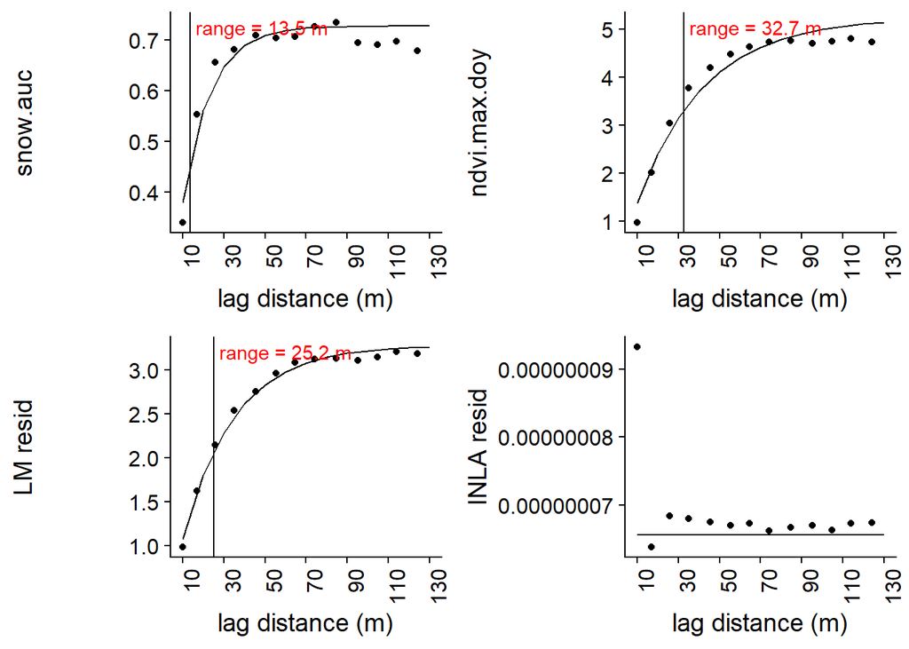

Graph fitted values and marginal predictions.

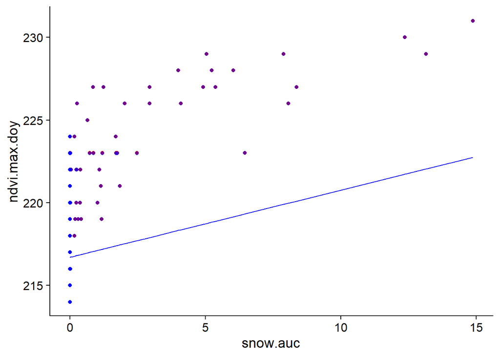

```r
# Graph data, fitted values and predictions
ggplot(data = input.data) +
  geom_point(aes(x = snow.auc, y= ndvi.max.doy),
             colour = 'red') +
  geom_point(aes(x = snow.auc, y = fitted),
             colour = "blue",
             alpha = 0.5) +
  geom_line(aes(x = snow.auc, preds),
            colour = "blue") +
  theme_cowplot()
```

The fitted values (blue) are very close to the observed values (red). Suggesting that the model (including the spatial random effect) does manage to account for a lot of the variation in the data (very good!). The fitted slope and intercept seem both reasonable given the observed data.

Let’s have a look at how the predictions are distributed in space:

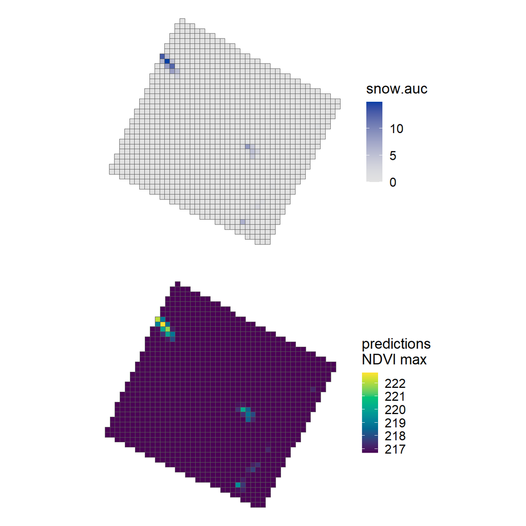

```r
plot_grid(ggplot() +
  geom_sf(data = st_buffer(input.data, 5, endCapStyle = "SQUARE"),
          aes(fill = snow.auc)) +
  scale_fill_continuous_sequential("blue") +
  labs(fill = "snow.auc") +
  theme_map(),
  ggplot() +
  geom_sf(data = st_buffer(input.data, 5, endCapStyle = "SQUARE"),
          aes(fill = preds)) +
  scale_fill_continuous_sequential("viridis", rev = F) +
  labs(fill = "predictions\nNDVI max") +
  theme_map(),
  nrow = 2)
```

This looks great and seems to make sense given the hypothesised relationship.

Next we need to check whether there is still any autocorrelation in the residuals and whether these follow a Gaussian distribution (as assumed).

## Graph residuals

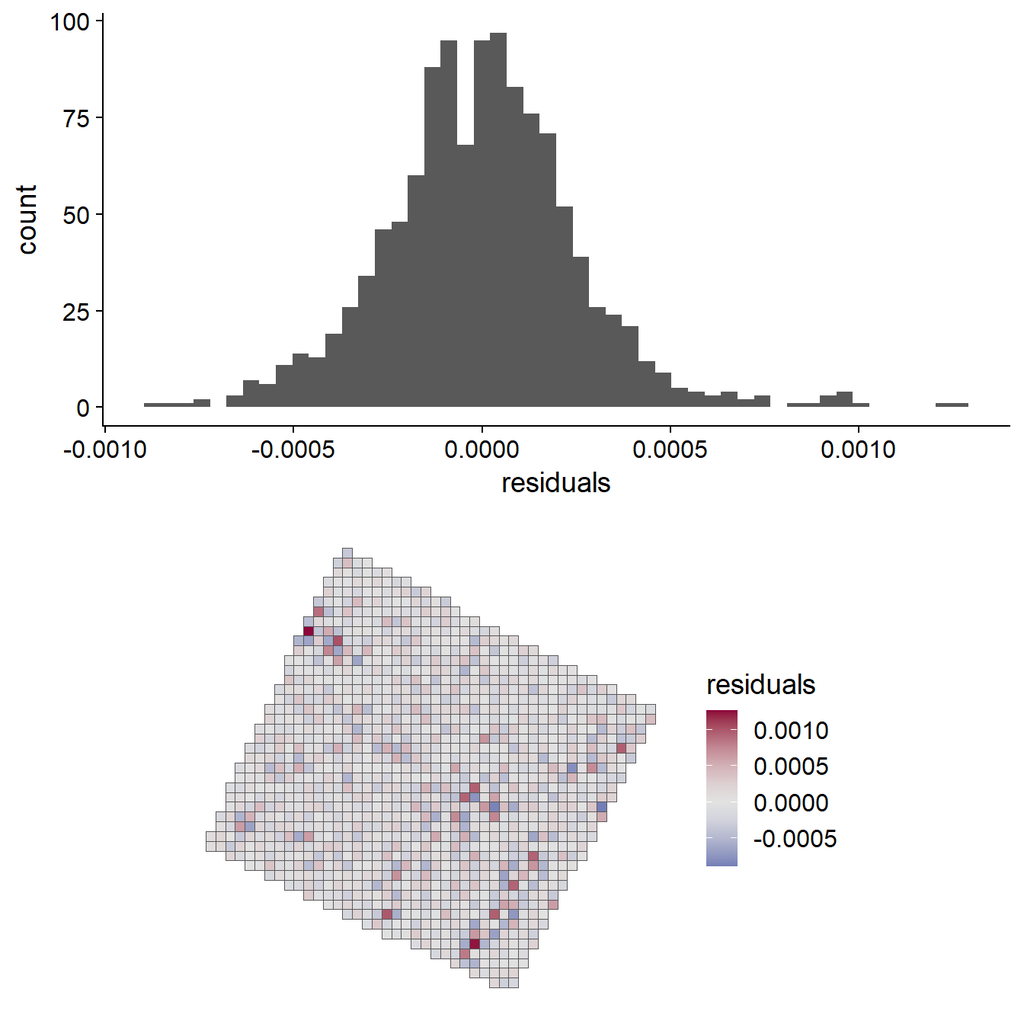

```r
# Graph residuals as histogram and in space
plot_grid(ggplot(input.data) +
  geom_histogram(aes(x = residuals), bins = 50) +
  labs(x = "residuals") +
  theme_cowplot(),
ggplot() +
  geom_sf(data = st_buffer(input.data, 5, endCapStyle = "SQUARE"), aes(fill = residuals)) +
  scale_fill_continuous_diverging() +
  theme_map(),
nrow = 2)
```

The histogram of the residuals follows a nice normal distribution - great!

It also seems like the model does an excellent job at accounting for the spatial autocorrelation. The residual are are seemingly randomly distributed in space.

As a last check, let’s look at the variation accounted for by the latent spatial effect.

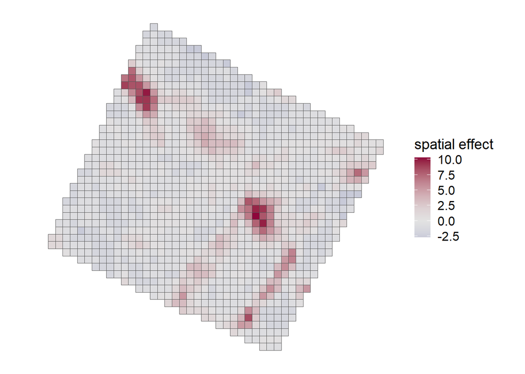

```r
ggplot() +
  geom_sf(data = st_buffer(input.data, 5, endCapStyle = "SQUARE"),
          aes(fill = ndvi.max.doy - preds - residuals)) +
  scale_fill_continuous_diverging() +
  labs(fill = "spatial effect") +
  theme_map()
```

The latent spatial effect of the model manages to account for a lot of the residual variation. That makes a lot of ecological sense, as we’d think that the majority in NDVI variation is not explained by our predictor.

# Blaesedalen, HLS S30

## Prepare “node” vector for INLA matern2d model

For NASA HLS S30 data, we can derive the column and row numbers from the UTM coordinates as follows:

col_number = (x - min(x)) / 30  
row_number = (max(y) - y) / 30

We can then assign a regularly increasing index (1:n), by infilling the cells no accounted for.

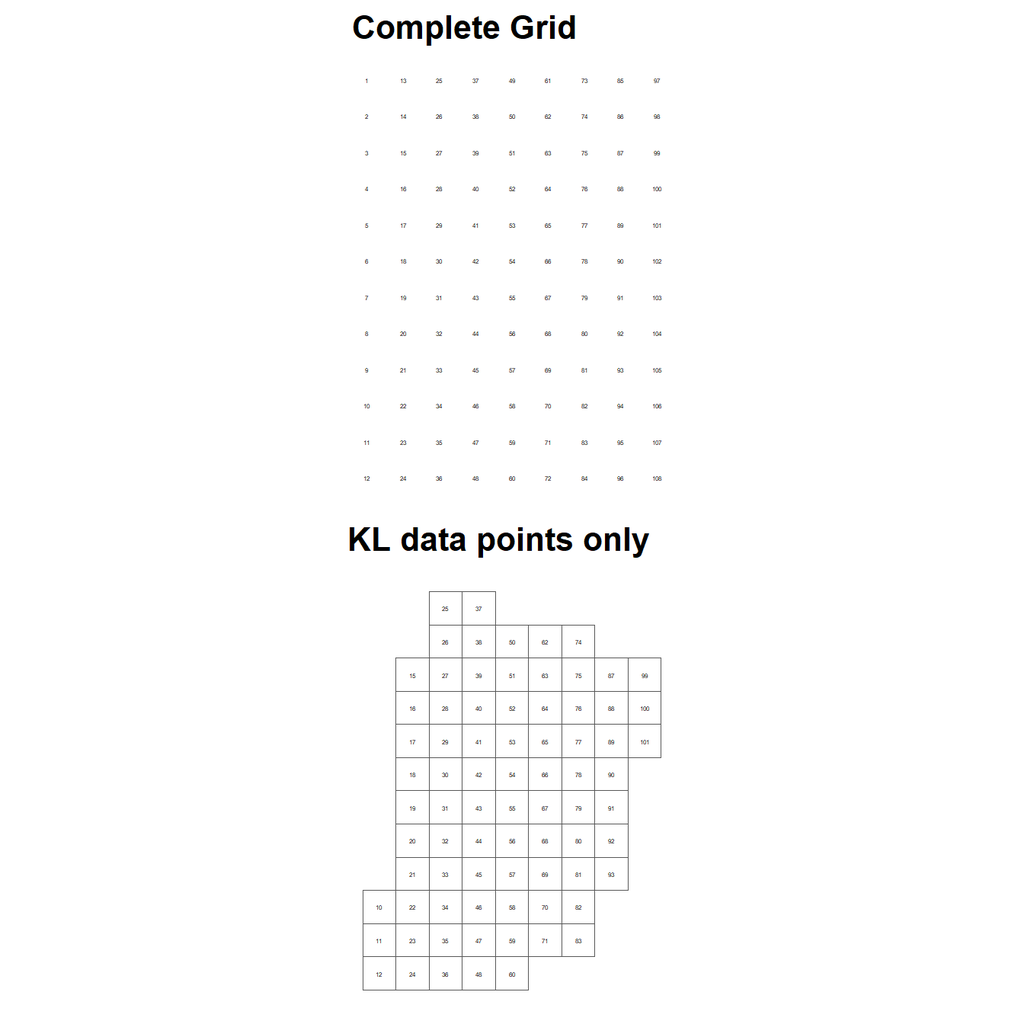

```r
# Calculate row and col_numbers
input.data <- s30.bl %>%
  # Calculate min X and max >
  mutate(min_x = min(.$X),
         max_y = max(.$Y)) %>%
  # Calczulate colum and row numbers for each cell (top-left to bottom-right corner)
  # We shift by one a R is 1- based
  mutate(col_number = 1 + ((X - min_x) / 30),
         row_number = 1 + ((max_y - Y) / 30)) %>%
  # Arrange dataset accordingly
  arrange(col_number, row_number)

# Derrive spatial index in INLA fashion (running number)
# Optain number of cols and rows
n_col = max(input.data$col_number)
n_row = max(input.data$row_number)
# Expand grid and add index
complete_grid <- expand.grid(1:n_col, 1:n_row) %>%
  # Rename columns
  select(col_number = Var1, row_number = Var2) %>%
  # Rearrange same as data frame above (top-left to bottom-right)
  arrange(col_number, row_number) %>%
  # Generate index ("node")
  mutate(node = 1:nrow(.))

# Add node to input.data, skipping those with no data (left_join)
input.data <- input.data %>%
  left_join(complete_grid, by = c("col_number", "row_number"))

# Plot to visualise
complete_grid_plot <- ggplot() +
  geom_text(data = complete_grid,
            mapping = aes(x = col_number, y = row_number, label = node),
            size = 1) +
  labs(title = "Complete Grid") +
  scale_y_reverse() +
  coord_equal() +
  theme_map()
kl_node_plot <- ggplot() +
  geom_sf(data = st_buffer(st_geometry(input.data), 15, endCapStyle = "SQUARE"),
          fill = NA) +
  geom_sf_text(data = input.data,
               aes(label = node),
               size = 1) +
  labs(title = "KL data points only") +
  theme_map()

plot_grid(complete_grid_plot,
          kl_node_plot,
          nrow = 2)
```

Now we have a vector (“node”) that represents the spatial arrangement of the pixels in a way that INLA can understand.

## Fitting a simple INLA model

Next, we fit a super simple INLA model, not worrying about priors for now.

```r
# Specify formula
formula_matern <- ndvi.max.doy ~ snow.auc +
                  f(node,
                    model = "matern2d",
                    nrow = n_row,
                    ncol = n_col)
# Fit model
model_matern <- inla(formula = formula_matern,
                     data = input.data,
                     family = "gaussian",
                     control.predictor = list(compute = TRUE),
                     control.compute = list(dic = TRUE,
                                            waic = TRUE,
                                            cpo = TRUE,
                                            return.marginals.predictor = TRUE),
                     keep = TRUE)
# Print summary
summary(model_matern)
```

```
##
## Call:
##    c("inla.core(formula = formula, family = family, contrasts = contrasts,
##    ", " data = data, quantiles = quantiles, E = E, offset = offset, ", "
##    scale = scale, weights = weights, Ntrials = Ntrials, strata = strata,
##    ", " lp.scale = lp.scale, link.covariates = link.covariates, verbose =
##    verbose, ", " lincomb = lincomb, selection = selection, control.compute
##    = control.compute, ", " control.predictor = control.predictor,
##    control.family = control.family, ", " control.inla = control.inla,
##    control.fixed = control.fixed, ", " control.mode = control.mode,
##    control.expert = control.expert, ", " control.hazard = control.hazard,
##    control.lincomb = control.lincomb, ", " control.update =
##    control.update, control.lp.scale = control.lp.scale, ", "
##    control.pardiso = control.pardiso, only.hyperparam = only.hyperparam,
##    ", " inla.call = inla.call, inla.arg = inla.arg, num.threads =
##    num.threads, ", " keep = keep, working.directory = working.directory,
##    silent = silent, ", " inla.mode = inla.mode, safe = FALSE, debug =
##    debug, .parent.frame = .parent.frame)" )
## Time used:
##     Pre = 1.11, Running = 2.09, Post = 0.253, Total = 3.45
## Fixed effects:
##                mean    sd 0.025quant 0.5quant 0.975quant    mode kld
## (Intercept) 217.117 0.563    216.010  217.117    218.224 217.117   0
## snow.auc      1.399 0.126      1.152    1.399      1.647   1.399   0
##
## Random effects:
##   Name     Model
##     node Matern2D model
##
## Model hyperparameters:
##                                              mean        sd 0.025quant
## Precision for the Gaussian observations     0.115     0.019      0.083
## Precision for node                      22055.089 24244.578   1469.189
## Range for node                            110.187   120.745      7.356
##                                          0.5quant 0.975quant     mode
## Precision for the Gaussian observations     0.114      0.155    0.112
## Precision for node                      14454.360  86421.558 4004.170
## Range for node                             72.338    430.781   20.060
##
## Deviance Information Criterion (DIC) ...............: 395.98
## Deviance Information Criterion (DIC, saturated) ....: 83.56
## Effective number of parameters .....................: 2.98
##
## Watanabe-Akaike information criterion (WAIC) ...: 395.74
## Effective number of parameters .................: 2.62
##
## Marginal log-Likelihood:  -213.86
## CPO, PIT is computed
## Posterior summaries for the linear predictor and the fitted values are computed
## (Posterior marginals needs also 'control.compute=list(return.marginals.predictor=TRUE)')
```

The credible interval does not overlap with zero, or, given the data and model the 95% interval of the posterior distribution indicates a positive slope with a mean of 1.399.

Let’s retrieve the fitted values and marginal predictions.

```r
# Calculate marginal predictions depending on snow.auc only
input.data$preds <- model_matern$summary.fixed[1,1] +
                 input.data$snow.auc * model_matern$summary.fixed[2,1]
# Add model fitted values and residuals to data frame
input.data$fitted <- model_matern$summary.linear.predictor$mean
input.data$residuals <- input.data$ndvi.max.doy - model_matern$summary.linear.predictor$mean
```

Produce variograms to better understand the spatial structure of the data and to assess whether the INLA model with non-informative priors appropriately accounts for spatial autocorrelation.

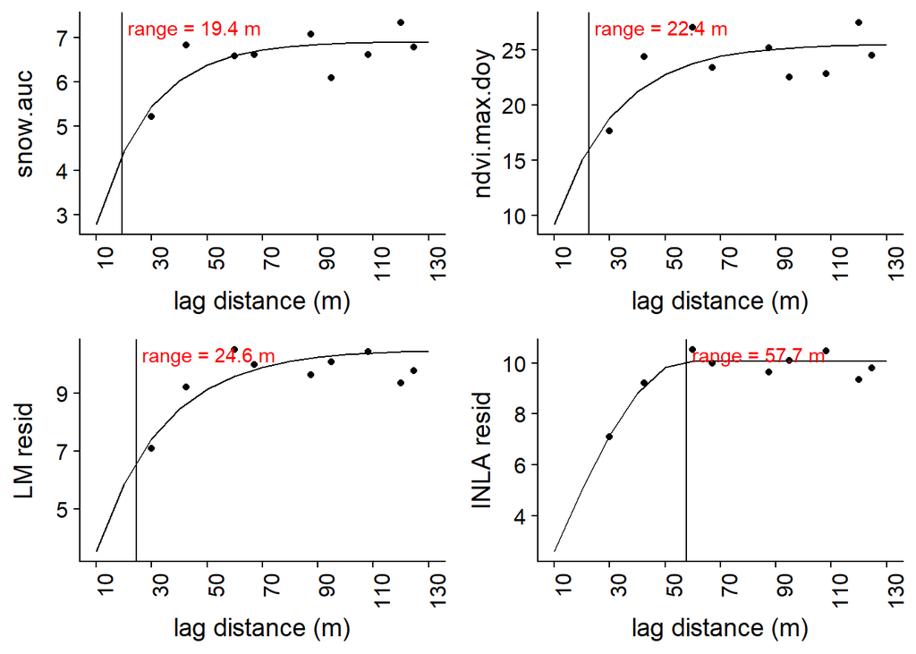

```r
# Fit variogram snow
vario_snow <- as_Spatial(input.data) %>% as("SpatialPointsDataFrame") %>%
  variogram(snow.auc ~ 1, data = ., cutoff = 130, width = 10)
vario_snow.max_fit <- fit.variogram(vario_snow, model = vgm(model = "Mat"))


# Visualise results
vario.snow <- ggplot(data = vario_snow) +
    geom_point(aes(x = dist, y = gamma)) +
    geom_line(aes(x = dist, y = gamma),
              data = variogramLine(vario_snow.max_fit,
                                   dist_vector = seq(10,130,10))) +
    geom_vline(xintercept = vario_snow.max_fit$range) +
    annotate("text", x = vario_snow.max_fit$range, y  = Inf,
             label = paste0(" range = ", round(vario_snow.max_fit$range, 1), " m"),
             hjust = 0, vjust = 1.5, color = 'red') +
    scale_x_continuous(limits = c(10, 130), breaks = seq(10,130,20)) +
    labs(x = "lag distance (m)", y = "snow.auc") +
    theme_cowplot() +
    theme(axis.text.x = element_text(angle = 90, hjust = 1))


# Fit variogram ndvi max doy
vario_doy <- as_Spatial(input.data) %>% as("SpatialPointsDataFrame") %>%
  variogram(ndvi.max.doy ~ 1, data = ., cutoff = 130, width = 10)
vario_doy.max_fit <- fit.variogram(vario_doy, model = vgm(model = "Mat"))


# Visualise results
vario.doy <- ggplot(data = vario_doy) +
    geom_point(aes(x = dist, y = gamma)) +
    geom_line(aes(x = dist, y = gamma),
              data = variogramLine(vario_doy.max_fit,
                                   dist_vector = seq(10,130,10))) +
    geom_vline(xintercept = vario_doy.max_fit$range) +
    annotate("text", x = vario_doy.max_fit$range, y  = Inf,
             label = paste0(" range = ", round(vario_doy.max_fit$range, 1), " m"),
             hjust = 0, vjust = 1.5, color = 'red') +
    scale_x_continuous(limits = c(10, 130), breaks = seq(10,130,20)) +
    labs(x = "lag distance (m)", y = "ndvi.max.doy") +
    theme_cowplot() +
    theme(axis.text.x = element_text(angle = 90, hjust = 1))

# LM residuals variogram

# Fit variogram linear model
doy.snow.lm <- lm(input.data$ndvi.max.doy ~ input.data$snow.auc)

# Fit variogram residuals
vario_resid_lm <- input.data %>% mutate(lm.resid = doy.snow.lm$residuals) %>%
  as_Spatial() %>%
  as("SpatialPointsDataFrame") %>%
  variogram(lm.resid ~ 1, data = ., cutoff = 130, width = 10)
vario_resid_lm_fit <- fit.variogram(vario_resid_lm, model = vgm(model = "Mat"))


# Visualise results
vario.lm <- ggplot(data = vario_resid_lm) +
    geom_point(aes(x = dist, y = gamma)) +
    geom_line(aes(x = dist, y = gamma),
              data = variogramLine(vario_resid_lm_fit,
                                   dist_vector = seq(10,130,10))) +
    geom_vline(xintercept = vario_resid_lm_fit$range) +
    annotate("text", x = vario_resid_lm_fit$range, y  = Inf,
             label = paste0(" range = ", round(vario_resid_lm_fit$range, 1), " m"),
             hjust = 0, vjust = 1.5, color = 'red') +
    scale_x_continuous(limits = c(10, 130), breaks = seq(10,130,20)) +
    labs(x = "lag distance (m)", y = "LM resid") +
    theme_cowplot() +
    theme(axis.text.x = element_text(angle = 90, hjust = 1))


# INLA model residuals variogram
vario_resid_inla <- input.data %>%
  as_Spatial() %>%
  as("SpatialPointsDataFrame") %>%
  variogram(residuals ~ 1, data = ., cutoff = 130, width = 10)
vario_resid_inla_fit <- fit.variogram(vario_resid_inla, model = vgm(model = "Sph"))
# Visualise results
vario.inla <- ggplot(data = vario_resid_inla) +
    geom_point(aes(x = dist, y = gamma)) +
    geom_line(aes(x = dist, y = gamma),
              data = variogramLine(vario_resid_inla_fit,
                                   dist_vector = seq(10,130,10))) +
    geom_vline(xintercept = vario_resid_inla_fit$range) +
    annotate("text", x = vario_resid_inla_fit$range, y  = Inf,
             label = paste0(" range = ", round(vario_resid_inla_fit$range, 1), " m"),
             hjust = 0, vjust = 1.5, color = 'red') +
    scale_x_continuous(limits = c(10, 130), breaks = seq(10,130,20)) +
    labs(x = "lag distance (m)", y = "INLA resid") +
    theme_cowplot() +
    theme(axis.text.x = element_text(angle = 90, hjust = 1))

plot_grid(vario.snow, vario.doy,
          vario.lm, vario.inla,
          align = 'v',
          ncol = 2,
          nrow = 2)
```

Graph fitted values and marginal predictions.

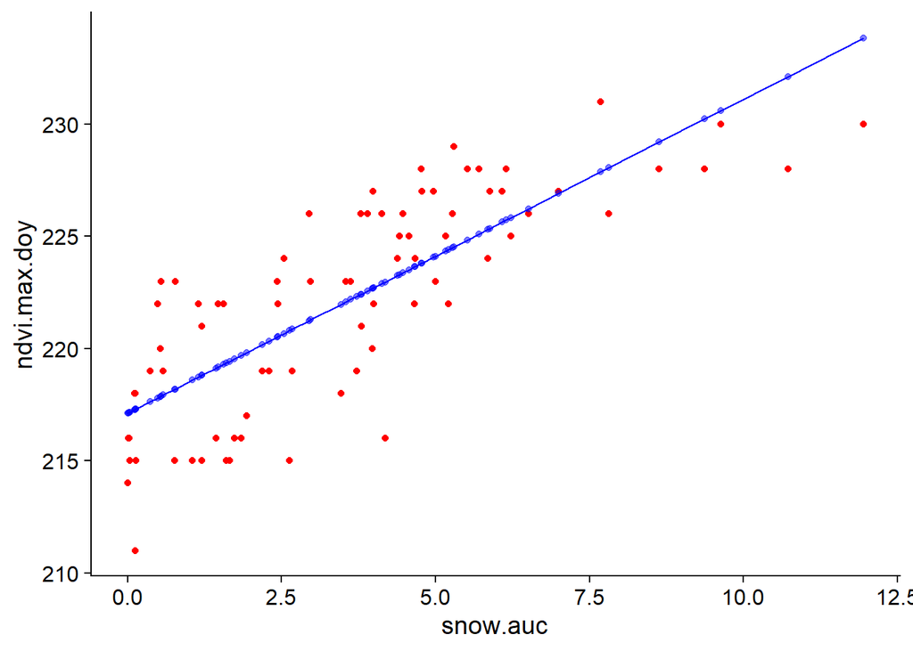

```r
# Graph data, fitted values and predictions
ggplot(data = input.data) +
  geom_point(aes(x = snow.auc, y= ndvi.max.doy),
             colour = 'red') +
  geom_point(aes(x = snow.auc, y = fitted),
             colour = "blue",
             alpha = 0.5) +
  geom_line(aes(x = snow.auc, preds),
            colour = "blue") +
  theme_cowplot()
```

Let’s have a look at how the predictions are distributed in space:

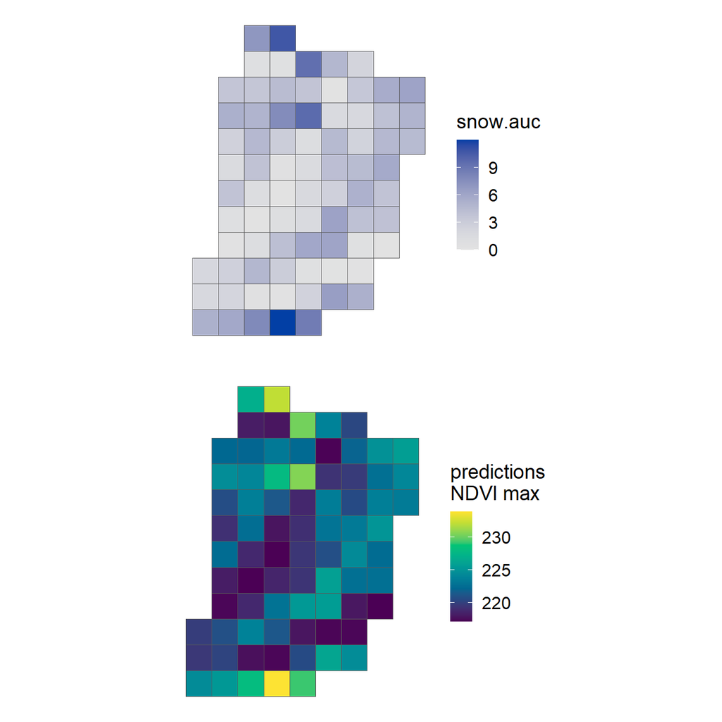

```r
plot_grid(ggplot() +
  geom_sf(data = st_buffer(input.data, 15, endCapStyle = "SQUARE"),
          aes(fill = snow.auc)) +
  scale_fill_continuous_sequential("blue") +
  labs(fill = "snow.auc") +
  theme_map(),
  ggplot() +
  geom_sf(data = st_buffer(input.data, 15, endCapStyle = "SQUARE"),
          aes(fill = preds)) +
  scale_fill_continuous_sequential("viridis", rev = F) +
  labs(fill = "predictions\nNDVI max") +
  theme_map(),
  nrow = 2)
```

This looks great and seems to make sense given the hypothesised relationship.

Next we need to check whether there is still any autocorrelation in the residuals and whether these follow a Gaussian distribution (as assumed).

## Graph residuals

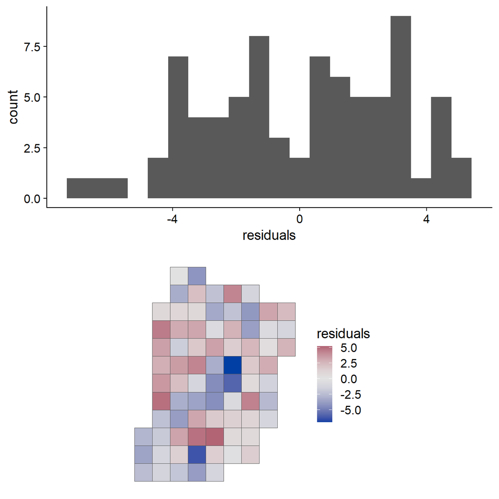

```r
# Graph residuals as histogram and in space
plot_grid(ggplot(input.data) +
  geom_histogram(aes(x = residuals), bins = 20) +
  labs(x = "residuals") +
  theme_cowplot(),
ggplot() +
  geom_sf(data = st_buffer(input.data, 15, endCapStyle = "SQUARE"), aes(fill = residuals)) +
  scale_fill_continuous_diverging() +
  theme_map(),
nrow = 2)
```

As a last check, let’s look at the variation accounted for by the latent spatial effect.

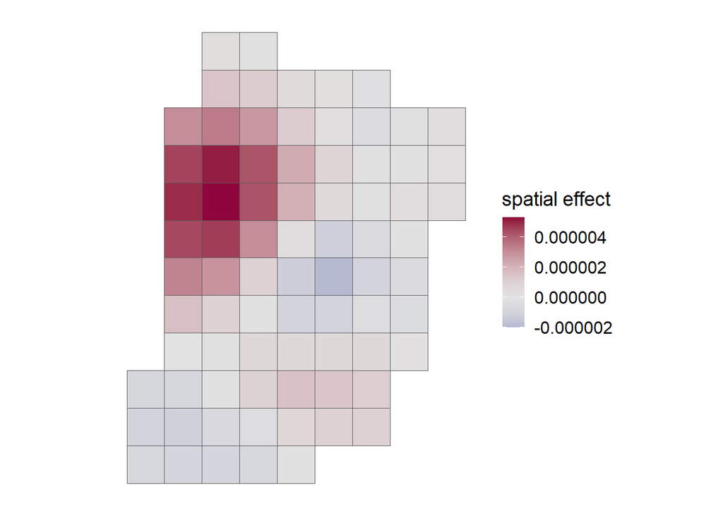

```r
ggplot() +
  geom_sf(data = st_buffer(input.data, 15, endCapStyle = "SQUARE"),
          aes(fill = ndvi.max.doy - preds - residuals)) +
  scale_fill_continuous_diverging() +
  labs(fill = "spatial effect") +
  theme_map()
```